# Qualtrics_Cleaning

misha !

2023-08-02

1. Loading Packages and Data
2. Read Data
3. Rename columns and make a dataset of kids
4. DATASET WITH NO DUPLICATES:

Making a dataset of kids with no duplicates. I used parent name, but we could use something else to decide when kids are duplicates.

5. This is the new dataset. I’m just keeping the old column names, and adding a participation column name
6. I wrote the following function to remove duplicates. Summary of the function is below and details for each line of code are included: Take the participant name; Search for participant name in participant name column; If match ==1, then add to database; If match >=2, then take all matches and add to a different database; Check for most complete version; Keep all with most complete version; Check date. Keep one with the most recent date; This results in prioritizing completion then date; Add to the database.
7. Clean Data:
8. Making the Free responses consistent:

DOB

Child Gender (will need to be updated year after year)

```
##
##      Blank     Female       Male Non-Binary
##         78        696        655          1
```

Making the Free responses consistent: Child Ethnicity (will need to be updated year after year)

```
##
## American Indian/Alaskan Native                          Asian
##                             21                            203
##                          Black                Hispanic/Latino
##                             50                             58
##                          Hmong                 Middle Eastern
##                              4                              8
##            Multiple Categories                    No response
##                            162                            154
##               Pacific Islander                Uncategorizable
##                              7                            321
##                          White
##                            442
```

Parent 1/2 Ethnicity

```
##
## American Indian/Alaskan Native                          Asian
##                             48                            212
##                          Black                Hispanic/Latino
##                             63                             79
##            Multiple Categories                    No response
##                             74                            158
##                          Other                          White
##                             31                            765
```

```
##
## American Indian/Alaskan Native                          Asian
##                             19                             71
##                          Black                Hispanic/Latino
##                             26                             40
##            Multiple Categories                    No response
##                             36                            762
##                Uncategorizable                          White
##                             12                            464
```

Parent 1/2 Religion

```
##
##        Agnostic         Atheist        Catholic       Christian           Hindu
##              21             109             140             208              41
##           Islam         Judaism             LDS    Not Answered           Other
##              33              65              49             464              20
## Uncategorizable
##               7
```

```
##
##     Agnostic      Atheist     Catholic    Christian        Hindu        Islam
##           21           69           69           93           15           12
##      Judaism          LDS Not Answered        Other
##           42           28          898           11
```

JWB Sum

InGroup Sum

# Graphs

Re-leveling and plotting Graphs

Household income

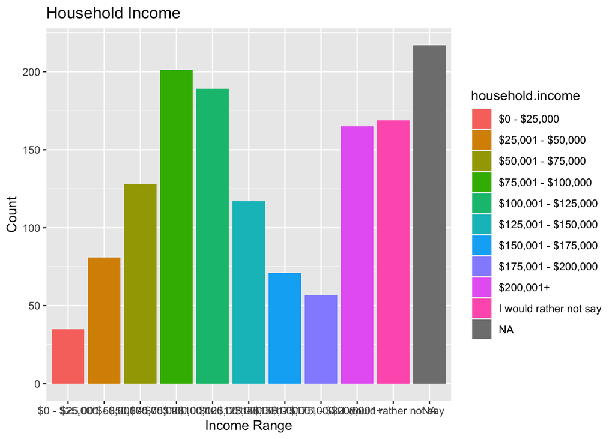

Graphing repeat participants

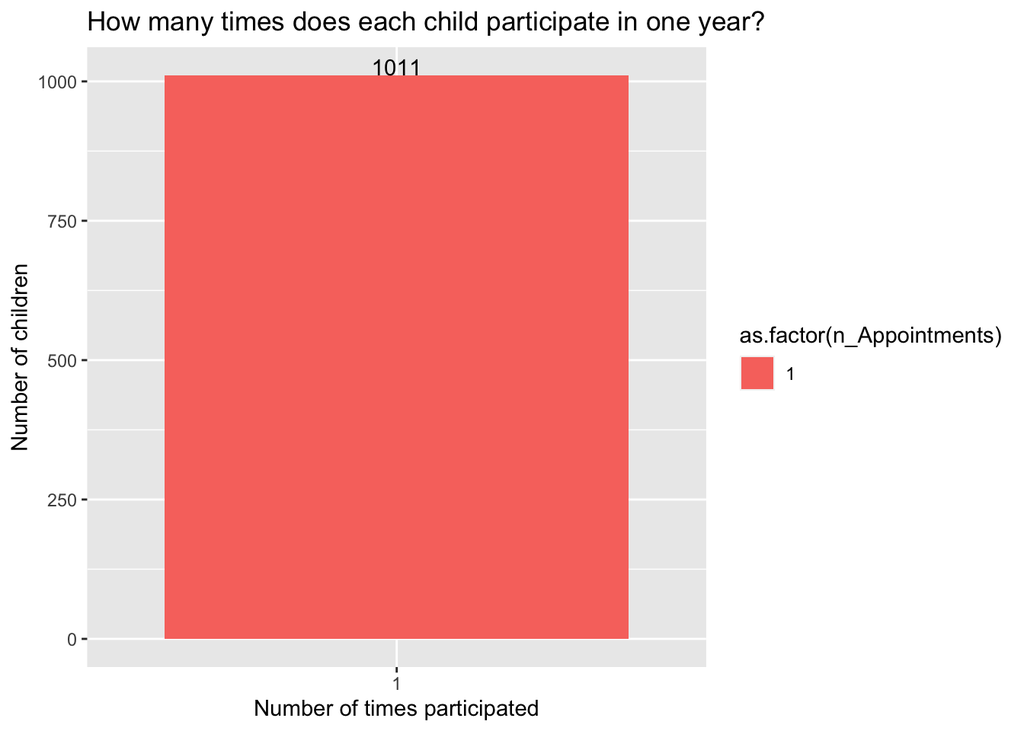

Parent 1 Party/Politics Graph

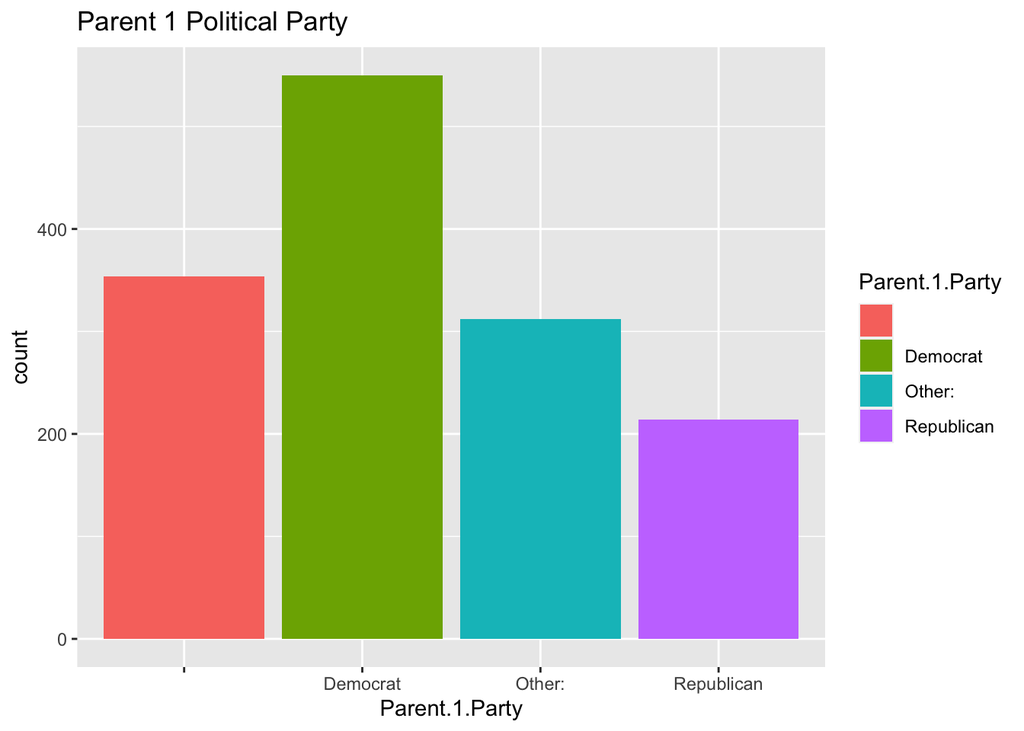

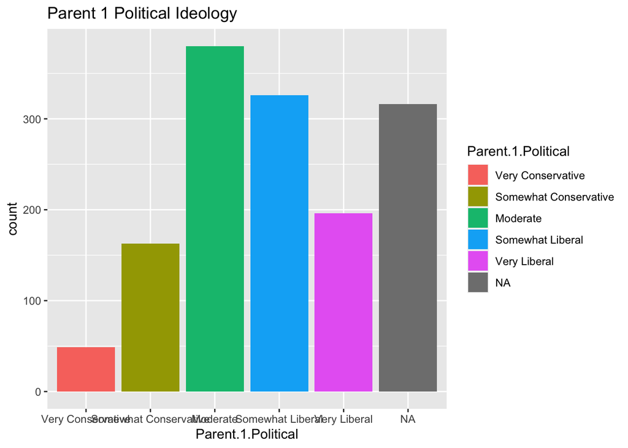

Parent 2 Party/Politics Graph

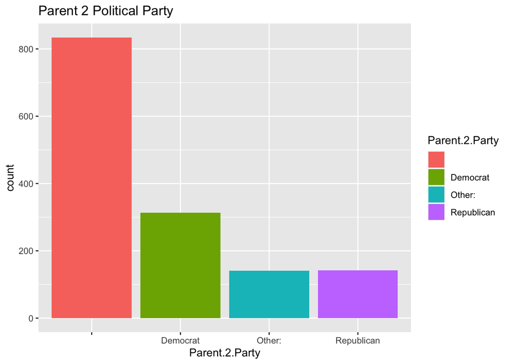

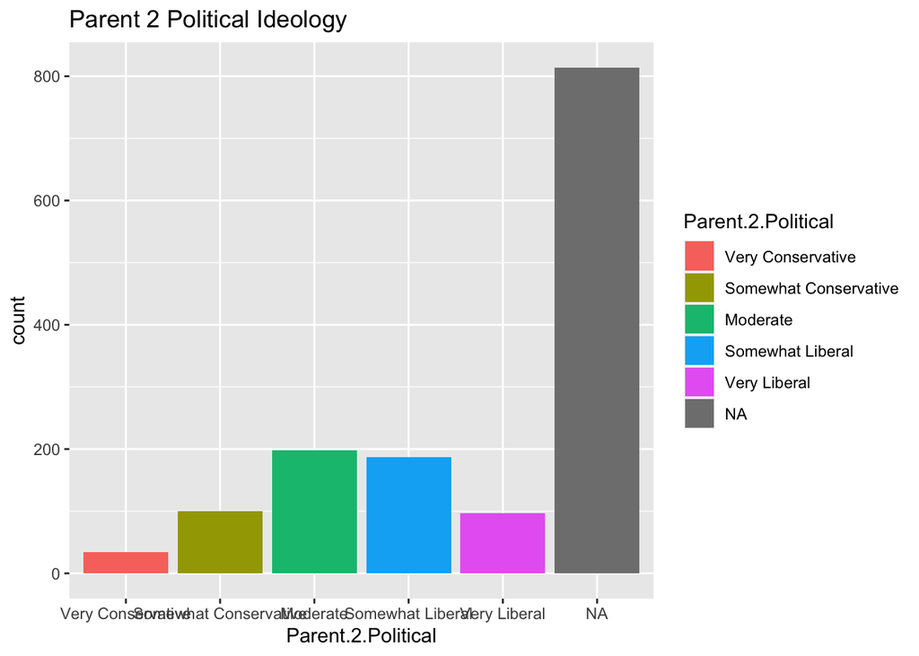

Religion Graphs

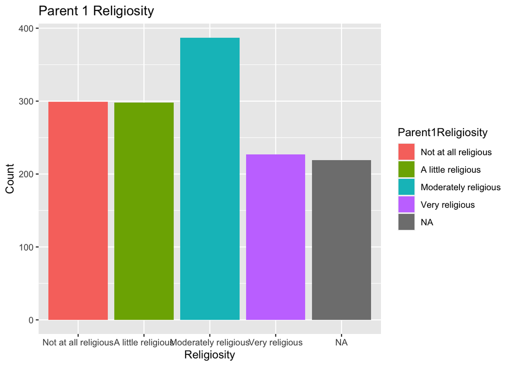

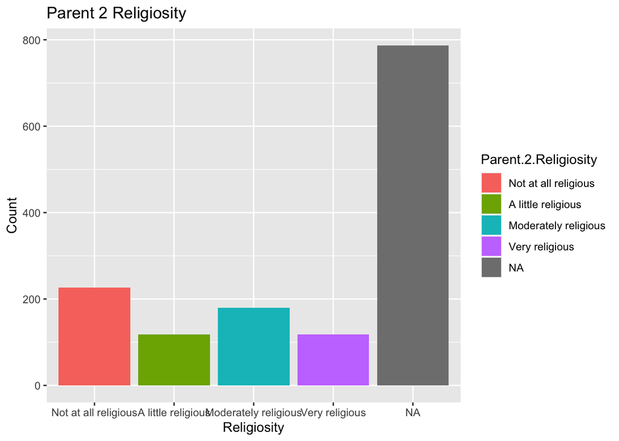

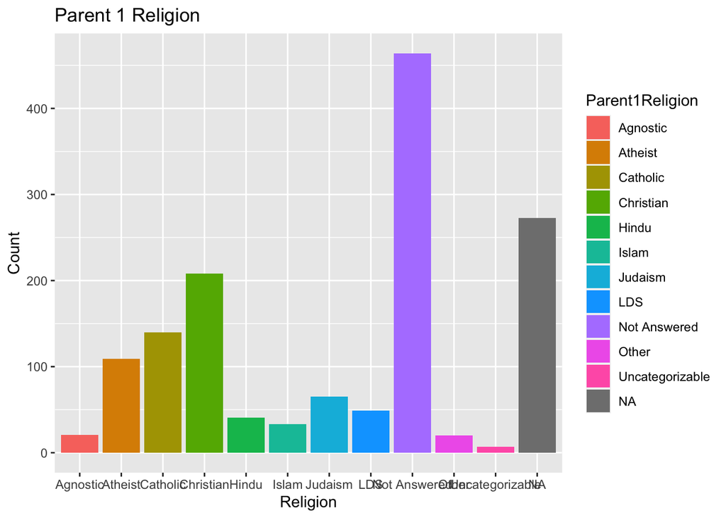

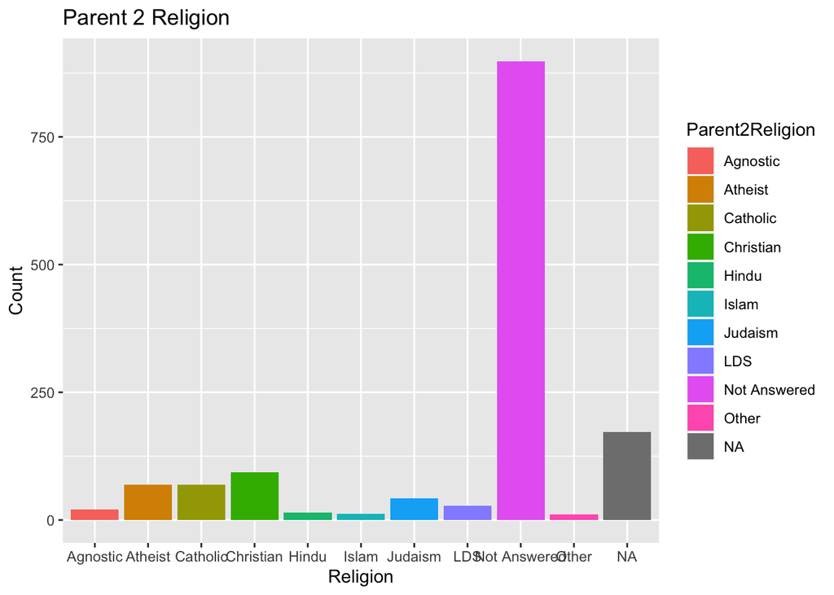

Education Graph(s)

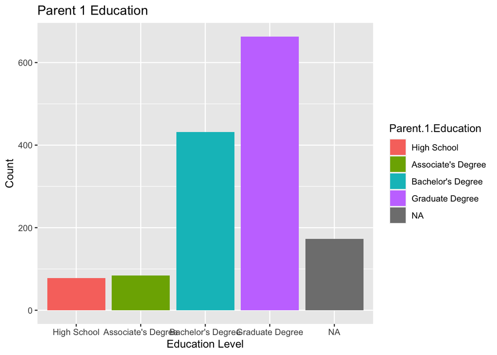

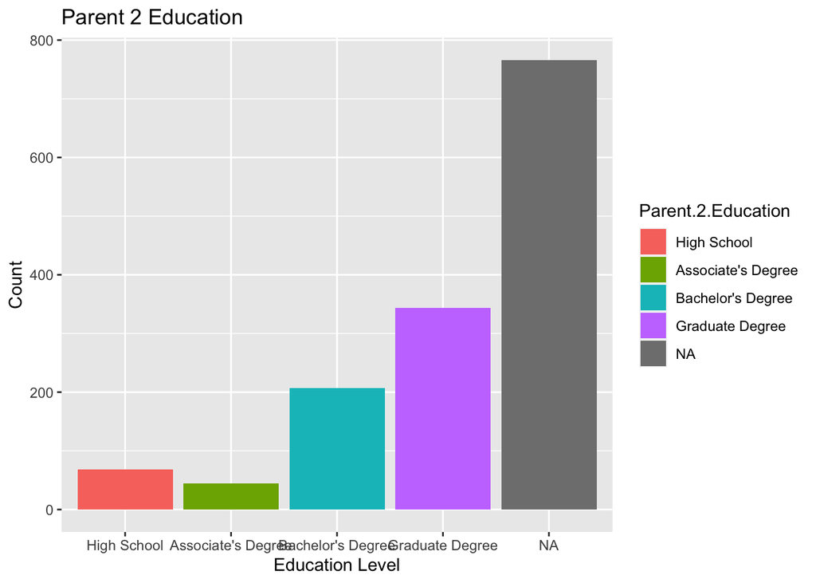

When do we get most of our participants?

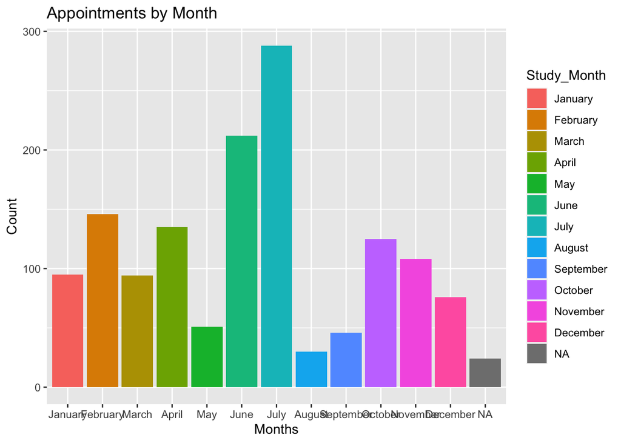

Mapping Participants

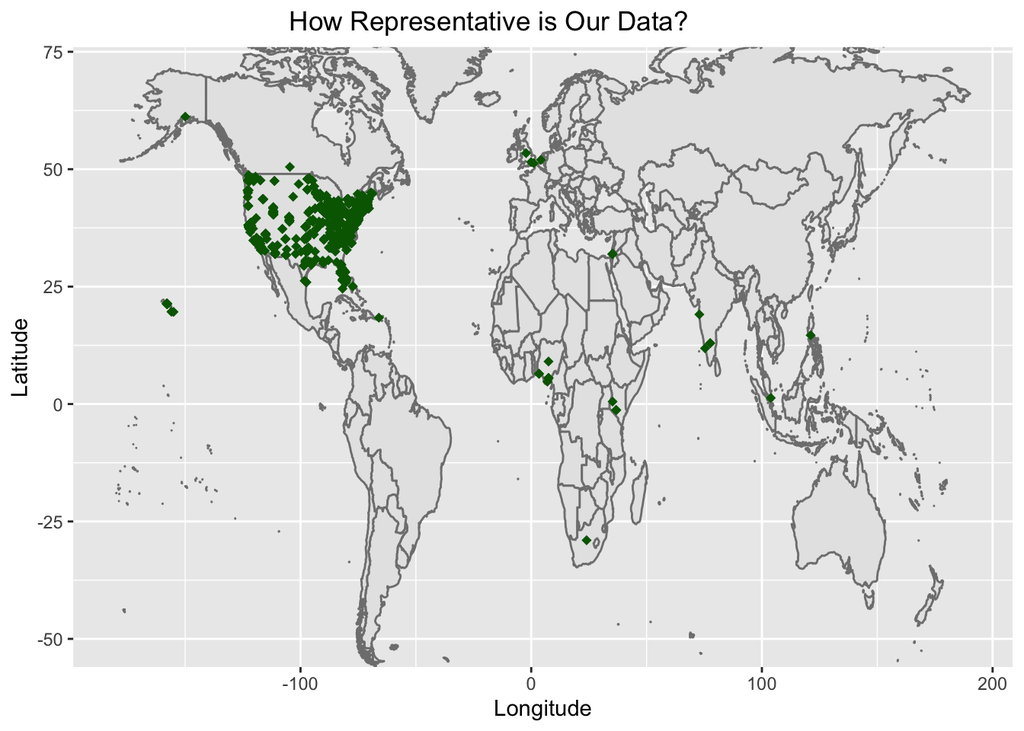